# BrainStation Challenge - Kickstarter

You can download the notebook from my Github repository: [Kickstarter campaign](https://github.com/rodrickmascarenhas/brainstarter-kickstarter/)

As a small board game company starting their Kickstarter campaign, the company requires a minimum of $15,000 to launch the project off the ground. They are hiring one of the best consultants to deliver a business report on trends, insights, and recommendations from a dataset on Kickstarter's campaigns. Using SQL and Excel to visualize data, they are searching for answers to three important questions.

- Question 1: What is a realistic Kickstarter campaign goal (in dollars) should the company aim to raise?
- Question 2: How many backers will be needed to meet their goal?
- Question 3: How many backers can the company realistically expect, based on trends in their category?

In addition, there are a list of questions the executives would like to find out in our preliminary analysis using SQL:

1. Are the goals for dollars raised significantly different between campaigns that are successful and unsuccessful?
2. What are the top/bottom 3 categories with the most backers? What are the top/bottom 3 subcategories by backers?
3. What are the top/bottom 3 categories that have raised the most money? What are the top/bottom 3 subcategories that have raised the most money?
4. Rank the top three countries with the most successful campaigns in terms of dollars (total amount pledged), and in terms of the number of campaigns backed.
5. Do longer, or shorter campaigns tend to raise more money? Why?

#### Preliminary Analysis

1. The average goal of failed campaigns is 10x higher than that of successful campaigns. Usually, lack of ideation and traction with buyers may lead to devaluation.

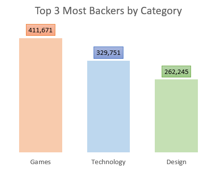

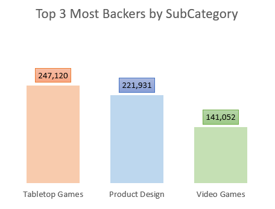

2. Majority of backers invest in Games, Technology and Design categories. By deepening our understanding of subcategories, majority of backers invest in Tabletop Games, Product Design and Video Games in particular.

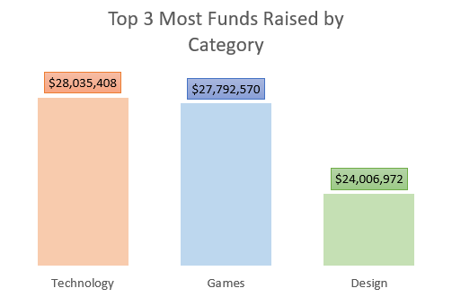

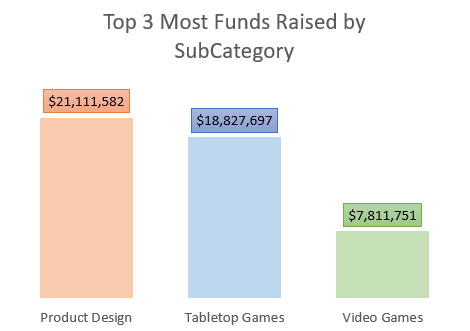

3. Majority of funds raised are delivered to Technology, Games and Design categories. By deepening our understanding of subcategories, majority of funds raised are delivered to Product Design, Tabletop Games and Video Games in particular.

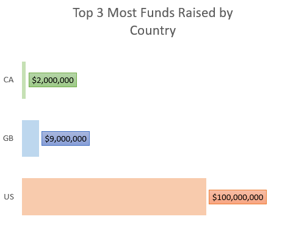

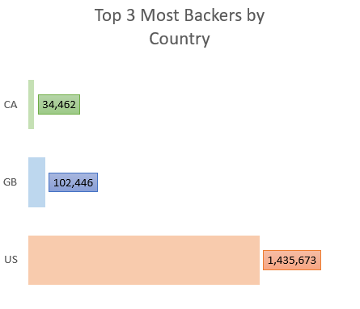

4. United States, Great Britain and Canada are among the top 3 crowdfunding countries amassing the most backers and funds raised worldwide.

[figure not shown]

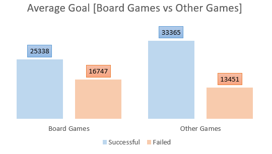

#### Final Recommendations

**Question 1:** What is a realistic Kickstarter campaign goal (in dollars) should the company aim to raise?

**A:** The company should aim to raise $25,000 to expand their business as per the success rate of board game companies

**Question 2:** How many backers will be needed to meet their goal?

**A:** Several board game companies had success to raise $25,000 with just over 300 backers. That is 81$ per backer.

**Question 3:** How many backers can the company realistically expect, based on trends in their category?

**A:** Board game companies require less funding as compared to other game companies. With that said, game companies in general require at least 360 backers to meet a target of $25,000.